# Boosted Trees

## Boosting

### Adaboost

** Train decision tree with equal weights ** Increase or lower the weights of the observations which are difficult to classify and easy to classify respectively. ** Second tree is grown upon the weighted data

**New Model is Tree1 + Tree2

** Classification error from this new 2-tree ensemble model ** Grow 3rd tree to predict the revised residuals ** Repeat this process for specified number of iteration

### Gradient Boosting Machine

**(Gradient Boosting = Gradient Descent + Boosting)

** Fit an additive model (ensemble) in a forward stagewise manner. ** In each stage introduce a weak learner (eg; decision tree) to compensate the shortcomings of existing learners. ** In Adaboost shortcoming are identified by high weights data points. ** In gradient boosting, shortcomings are identified by gradients.

#### Train a GBM model

```r
# Convert "yes" to 1, "no" to 0
credit_train$default <- ifelse(credit_train$default == "yes", 1, 0)

# Train a 10000-tree GBM model
set.seed(1)
credit_model <- gbm(formula = default ~ .,
                    distribution = "bernoulli",
                    data = credit_train,
                    n.trees = 10000)

# Print the model object
print(credit_model)

# summary() prints variable importance
summary(credit_model)
```

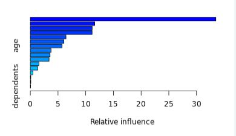

GBM_plot1

#### Understing the GBM Model output

**summary(model) gives the relative importance for each variable.

```r
# Since we converted the training response col, let's also convert the test response col
credit_test$default <- ifelse(credit_test$default == "yes", 1, 0)

# Generate predictions on the test set
preds1 <- predict(object = credit_model,
                  newdata = credit_test,
                  n.trees = 10000,
                type = "link")

# Generate predictions on the test set (scale to response)
preds2 <- predict(object = credit_model,
                  newdata = credit_test,
                  n.trees = 10000,
                  type = "response")

# Compare the range of the two sets of predictions
range(preds1)
range(preds2)

# Generate the test set AUCs using the two sets of preditions & compare
auc(actual = credit_test$default, predicted = preds1)  #default
auc(actual = credit_test$default, predicted = preds2)  #rescaled
```

## GBM Hyperparameter

### Tuning a gbm Model

#### GBM Hyper parameters

** ntrees: number of treess ** bag.fraction: proportion of observation to be sampled in each tree ** n.minobbsinodde: minimum number of observation in trees terminal nodes ** interaction.depth: maximum nodes per tree ** shrinkage: Learning rate

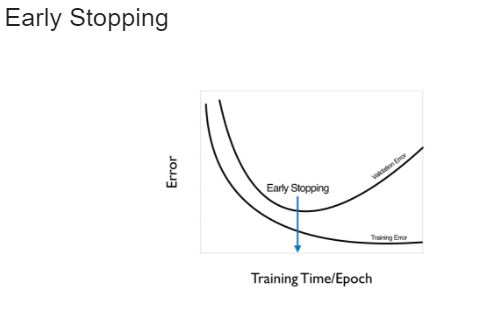

Early_Stopping

```r
# Optimal ntree estimate based on OOB
ntree_opt_oob <- gbm.perf(object = credit_model,
                          method = "OOB",
                          oobag.curve = TRUE)

# Train a CV GBM model
set.seed(1)
credit_model_cv <- gbm(formula = default ~ .,
                       distribution = "bernoulli",
                       data = credit_train,
                       n.trees = 10000,
                       cv.folds = 2)

# Optimal ntree estimate based on CV
ntree_opt_cv <- gbm.perf(object = credit_model_cv,
                         method = "cv")

# Compare the estimates
print(paste0("Optimal n.trees (OOB Estimate): ", ntree_opt_oob))
print(paste0("Optimal n.trees (CV Estimate): ", ntree_opt_cv))
```

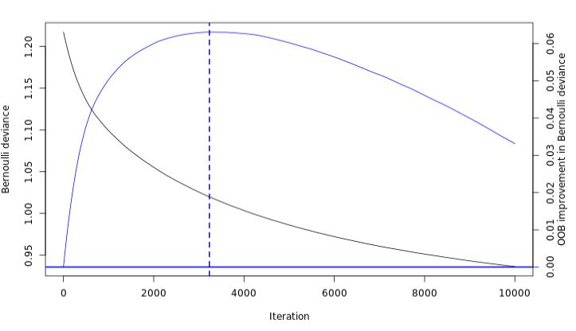

Bernoulli_Deviance

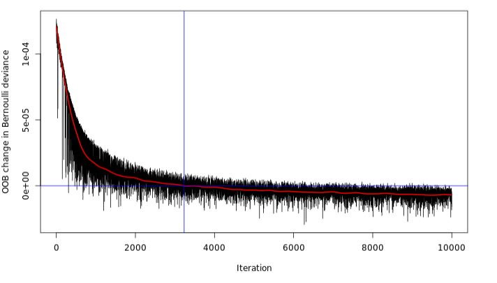

OOB_Bernoulli_Deviance

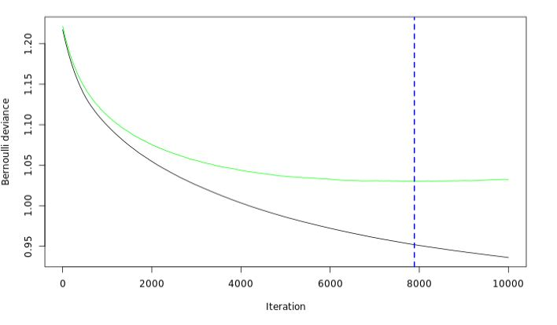

Bernoulli_Deviance2

## OOB vs CV-based early stopping

In the previous exercise, we used OOB error and cross-validated error to estimate the optimal number of trees in the GBM. These are two different ways to estimate the optimal number of trees, so in this exercise we will compare the performance of the models on a test set. We can use the same model object to make both of these estimates since the predict.gbm() function allows you to use any subset of the total number of trees (in our case, the total number is 10,000).

```r
# Generate predictions on the test set using ntree_opt_oob number of trees
preds1 <- predict(object = credit_model,
                  newdata = credit_test,
                  n.trees = ntree_opt_oob)

# Generate predictions on the test set using ntree_opt_cv number of trees
preds2 <- predict(object = credit_model,
                  newdata = credit_test,
                  n.trees = ntree_opt_cv)

# Generate the test set AUCs using the two sets of preditions & compare
auc1 <- auc(actual = credit_test$default, predicted = preds1)  #OOB
auc2 <- auc(actual = credit_test$default, predicted = preds2)  #CV

# Compare AUC
print(paste0("Test set AUC (OOB): ", auc1))
print(paste0("Test set AUC (CV): ", auc2))
```

### Compare and plot the ROC

```r
# Generate the test set AUCs using the two sets of predictions & compare
actual <- credit_test$default
dt_auc <- auc(actual = actual, predicted = dt_preds)
bag_auc <- auc(actual = actual, predicted = bag_preds)
rf_auc <- auc(actual = actual, predicted = rf_preds)
gbm_auc <- auc(actual = actual, predicted = gbm_preds)

# Print results
sprintf("Decision Tree Test AUC: %.3f", dt_auc)
sprintf("Bagged Trees Test AUC: %.3f", bag_auc)
sprintf("Random Forest Test AUC: %.3f", rf_auc)
sprintf("GBM Test AUC: %.3f", gbm_auc)


## Compare the ROC

# List of predictions
preds_list <- list(dt_preds, bag_preds, rf_preds, gbm_preds)

# List of actual values (same for all)
m <- length(preds_list)
actuals_list <- rep(list(credit_test$default), m)

# Plot the ROC curves
pred <- prediction(preds_list, actuals_list)
rocs <- performance(pred, "tpr", "fpr")
plot(rocs, col = as.list(1:m), main = "Test Set ROC Curves")
legend(x = "bottomright",
       legend = c("Decision Tree", "Bagged Trees", "Random Forest", "GBM"),
       fill = 1:m)
```

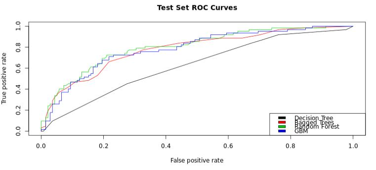

ROC_Curves